# Population Ageing in the World

Yu Liu

Link to the Github Webpage

Project Goal

This project uses data from https://databank.worldbank.org/source/population-estimates-and-projections#advancedDownloadOptions to illustrate the population ageing trends in the world.

Population ageing is becoming an increasingly more serious issue for many countries. When a country has the fraction of population aged 65 and above is equal to or larger than 7%, that country can be regarded as entering into population ageing society. The phenomenon is dominated by increasing life expectancy and declining fertility rates. I use 2000 and 2020 population data for all countries to demonstrate the trend.

There are three questions I'd like to answer:

1. Is population ageing a global issue?
2. What can we tell from the life expectancy trend?
3. What can we tell from the fertility rates changes?

```python
import os

current = os.getcwd()
print(current)
```

```
/content/Datasets
```

```python
%cd /content
!git clone https://github.com/kellyyliu/Datasets.git
%cd /content/Datasets
```

```
/content
Cloning into 'Datasets'...
remote: Enumerating objects: 18, done.
remote: Counting objects: 100% (18/18), done.
remote: Compressing objects: 100% (12/12), done.
remote: Total 18 (delta 4), reused 18 (delta 4), pack-reused 0
Receiving objects: 100% (18/18), 11.22 MiB | 8.08 MiB/s, done.
Resolving deltas: 100% (4/4), done.
/content/Datasets
```

```python
# Import data

import pandas as pd
import numpy as np
import matplotlib.pyplot as plt

wb_population = pd.read_csv('WB_Population.csv')

wb_population.head()
```

|  | Country Name | Country Code | Series Name | Series Code | 1960 [YR1960] | 1961 [YR1961] | 1962 [YR1962] | 1963 [YR1963] | 1964 [YR1964] | 1965 [YR1965] | ... | 2014 [YR2014] | 2015 [YR2015] | 2016 [YR2016] | 2017 [YR2017] | 2018 [YR2018] | 2019 [YR2019] | 2020 [YR2020] | 2021 [YR2021] | 2022 [YR2022] | 2023 [YR2023] |
| --- | --- | --- | --- | --- | --- | --- | --- | --- | --- | --- | --- | --- | --- | --- | --- | --- | --- | --- | --- | --- | --- |
| 0 | Afghanistan | AFG | Age dependency ratio (% of working-age populat... | SP.POP.DPND | 80.0511140452116 | 80.2223403638055 | 80.4019428356728 | 80.7153176723975 | 81.2195570776344 | 81.9948151777348 | ... | 94.7066970972784 | 93.0424476640396 | 92.0121249200047 | 90.5430941060045 | 89.0914511265535 | 87.649321552026 | 85.9595495980435 | 84.5992570171333 | 83.5703595136227 | 82.6159048623208 |
| 1 | Afghanistan | AFG | Age dependency ratio, old | SP.POP.DPND.OL | 5.10090106306272 | 5.0780879187975 | 5.04955848118009 | 5.02202041582739 | 4.99971912996147 | 4.98528747223266 | ... | 4.69079678722919 | 4.6442456380075 | 4.60635088670088 | 4.57268660954771 | 4.55160703424134 | 4.53690097986338 | 4.4945527274917 | 4.43787182461417 | 4.39530015497943 | 4.37390804047101 |
| 2 | Afghanistan | AFG | Age dependency ratio, young | SP.POP.DPND.YG | 74.9502129821489 | 75.144252445008 | 75.3523843544927 | 75.6932972565702 | 76.2198379476729 | 77.0095277055021 | ... | 90.0159003100492 | 88.3982020260321 | 87.4057740333038 | 85.9704074964568 | 84.5398440923121 | 83.1124205721626 | 81.4649968705518 | 80.1613851925191 | 79.1750593586432 | 78.2419968218498 |
| 3 | Afghanistan | AFG | Birth rate, crude (per 1,000 people) | SP.DYN.CBRT.IN | 50.34 | 50.443 | 50.57 | 50.703 | 50.831 | 50.872 | ... | 39.105 | 38.803 | 37.936 | 37.342 | 36.927 | 36.466 | 36.051 | 35.842 | .. | .. |
| 4 | Afghanistan | AFG | Death rate, crude (per 1,000 people) | SP.DYN.CDRT.IN | 31.921 | 31.349 | 30.845 | 30.359 | 29.867 | 29.389 | ... | 7.395 | 7.331 | 7.077 | 7.027 | 6.981 | 6.791 | 7.113 | 7.344 | .. | .. |

5 rows × 68 columns

```python
# Extract 2020 data

wb_population['2020 [YR2020]'].isna().sum()

wb_population_2020 = wb_population.loc[:,['Country Name','Series Name','2020 [YR2020]']]

wb_population_2020.head()

wb_population_2020_cube = wb_population_2020.pivot_table(
                            index = "Country Name", columns=["Series Name"],
                            values = "2020 [YR2020]", aggfunc=np.sum)
wb_population_2020_cube["year"] = 2020
wb_population_2020_cube
```

| Series Name Country Name | Age dependency ratio (% of working-age population) | Age dependency ratio, old | Age dependency ratio, young | Birth rate, crude (per 1,000 people) | Death rate, crude (per 1,000 people) | Fertility rate, total (births per woman) | Life expectancy at birth, female (years) | Life expectancy at birth, male (years) | Life expectancy at birth, total (years) | Mortality rate, adult, female (per 1,000 female adults) | ... | Probability of dying among youth ages 20-24 years (per 1,000) | Probability of dying at age 5-14 years (per 1,000 children age 5) | Rural population | Rural population (% of total population) | Rural population growth (annual %) | Sex ratio at birth (male births per female births) | Urban population | Urban population (% of total population) | Urban population growth (annual %) | year |
| --- | --- | --- | --- | --- | --- | --- | --- | --- | --- | --- | --- | --- | --- | --- | --- | --- | --- | --- | --- | --- | --- |
| Afghanistan | 85.9595495980435 | 4.4945527274917 | 81.4649968705518 | 36.051 | 7.113 | 4.75 | 65.432 | 59.866 | 62.575 | 210.053 | ... | 17.9 | .. | 28829317 | 73.974 | 2.76772385533188 | 1.052 | 10142913 | 26.026 | 4.18535706165902 | 2020 |
| Africa Eastern and Southern | 81.9689633250994 | 5.73311054063037 | 75.3108615538635 | 33.9167457004664 | 7.62054776213486 | 4.41690032191029 | 65.8364652190824 | 60.8174841935841 | 63.313860330682 | 224.232000876936 | ... | 13.4642698478062 | .. | 432797498 | 63.17169763064 | 1.884605854699 | 1.03229841001386 | 252315481 | 36.82830236936 | 4.06858924235209 | 2020 |
| Africa Western and Central | 86.3069202655725 | 5.38630996805807 | 80.5436398162813 | 36.6157297910259 | 10.6012972524141 | 5.0493293781153 | 58.3462397855696 | 56.1310226277444 | 57.2263727312399 | 297.189740156099 | ... | 12.151355866767 | .. | 243081107 | 52.142168975222 | 1.4436291654464 | 1.03687713765131 | 223107995 | 47.857831024778 | 3.92380423213898 | 2020 |
| Albania | 47.6966322543307 | 23.368744938597 | 24.3278873157337 | 10.285 | 10.785 | 1.4 | 79.676 | 74.632 | 76.989 | 56.31 | ... | 2 | .. | 1075204 | 37.888 | -2.87800331245244 | 1.078 | 1762645 | 62.112 | 0.85761092300088 | 2020 |
| Algeria | 57.889466858055 | 9.50095142470613 | 48.3885154333489 | 22.431 | 5.398 | 2.942 | 75.912 | 73.082 | 74.453 | 81.699 | ... | 3.1 | .. | 11413449 | 26.267 | -0.317427606600439 | 1.046 | 32038217 | 73.733 | 2.47298875191541 | 2020 |
| ... | ... | ... | ... | ... | ... | ... | ... | ... | ... | ... | ... | ... | ... | ... | ... | ... | ... | ... | ... | ... | ... |
| West Bank and Gaza | 75.1592317201693 | 6.01200482818728 | 69.1472268919821 | 28.8 | 3.489 | 3.57 | 76.683 | 72.164 | 74.403 | 82.815 | ... | 3.7 | .. | 1118249 | 23.281 | 1.2952752682179 | 1.051 | 3685020 | 76.719 | 2.8508765124279 | 2020 |
| World | 55.3545684516828 | 14.5279438228773 | 39.6127367015018 | 17.226395822445 | 8.03336842322587 | 2.29962648746436 | 74.8573033759887 | 69.799704821776 | 72.2438221110764 | 119.443111464671 | ... | 6.1 | .. | 3435440919 | 43.9362953861523 | 0.0245037316745993 | 1.05948444967827 | 4383700170 | 56.0637046138476 | 1.79829477842566 | 2020 |
| Yemen, Rep. | 75.1537231559569 | 4.7613542134381 | 70.3923689425188 | 31.252 | 6.509 | 3.886 | 67.885 | 61.636 | 64.65 | 163.202 | ... | 12.7 | .. | 20045810 | 62.092 | 1.29296541480667 | 1.059 | 12238236 | 37.908 | 3.99974403498889 | 2020 |
| Zambia | 83.1845162629024 | 3.16883578918599 | 80.0156804737164 | 34.953 | 6.602 | 4.379 | 65.043 | 59.643 | 62.38 | 225.21 | ... | 12.2 | .. | 10480465 | 55.371 | 1.93290333786957 | 1.011 | 8447250 | 44.629 | 4.18973799229941 | 2020 |
| Zimbabwe | 80.285254859982 | 6.08690279667854 | 74.1983520633034 | 31.009 | 8.132 | 3.545 | 63.862 | 58.129 | 61.124 | 295.007 | ... | 14.8 | .. | 10617452 | 67.758 | 1.98389097289518 | 1.024 | 5052214 | 32.242 | 2.13042091541727 | 2020 |

266 rows × 138 columns

```python
# Extract 2000 data

wb_population['2000 [YR2000]'].isna().sum()

wb_population_2000 = wb_population.loc[:,['Country Name','Series Name','2000 [YR2000]']]

wb_population_2000.head()

wb_population_2000_cube = wb_population_2000.pivot_table(
                            index = "Country Name", columns=["Series Name"],
                            values = "2000 [YR2000]", aggfunc=np.sum)
wb_population_2000_cube["year"] = 2000
wb_population_2000_cube
```

| Series Name Country Name | Age dependency ratio (% of working-age population) | Age dependency ratio, old | Age dependency ratio, young | Birth rate, crude (per 1,000 people) | Death rate, crude (per 1,000 people) | Fertility rate, total (births per woman) | Life expectancy at birth, female (years) | Life expectancy at birth, male (years) | Life expectancy at birth, total (years) | Mortality rate, adult, female (per 1,000 female adults) | ... | Probability of dying among youth ages 20-24 years (per 1,000) | Probability of dying at age 5-14 years (per 1,000 children age 5) | Rural population | Rural population (% of total population) | Rural population growth (annual %) | Sex ratio at birth (male births per female births) | Urban population | Urban population (% of total population) | Urban population growth (annual %) | year |
| --- | --- | --- | --- | --- | --- | --- | --- | --- | --- | --- | --- | --- | --- | --- | --- | --- | --- | --- | --- | --- | --- |
| Afghanistan | 108.346634638347 | 4.76031425052708 | 103.58632038782 | 49.664 | 12.096 | 7.534 | 56.858 | 53.762 | 55.298 | 290.083 | ... | 15.7 | .. | 15228282 | 77.922 | 1.32580608474027 | 1.065 | 4314700 | 22.078 | 1.86137729962901 | 2000 |
| Africa Eastern and Southern | 92.0447323060712 | 5.46284227621415 | 85.7689305616506 | 40.5282366204827 | 13.7756980933728 | 5.52355316105243 | 53.6622075489618 | 50.2368403625047 | 51.9644813247726 | 373.855468210979 | ... | 24.2033654636815 | .. | 286048935 | 71.2272200649119 | 2.17773260691155 | 1.03204438877095 | 115551653 | 28.7727799350881 | 3.60226233978761 | 2000 |
| Africa Western and Central | 90.0511094007867 | 5.85597363363416 | 84.0436144883948 | 43.199552914664 | 15.562004323077 | 6.02317868901341 | 51.3825284555454 | 49.0777124990516 | 50.221953875359 | 346.300398339523 | ... | 17.1785761620976 | .. | 174339008 | 64.6629506217044 | 2.00262708868885 | 1.04213268835693 | 95272890 | 35.3370493782956 | 4.14518949083499 | 2000 |
| Albania | 59.6572954321563 | 12.4883578855749 | 47.1689375465814 | 17.076 | 5.798 | 2.231 | 78.419 | 72.646 | 75.404 | 58.575 | ... | 5.3 | .. | 1799636 | 58.259 | -1.61439403235174 | 1.103 | 1289391 | 41.741 | 0.742478629285177 | 2000 |
| Algeria | 61.5008804071121 | 6.85352579262486 | 54.6473546144873 | 19.543 | 5.037 | 2.566 | 71.949 | 69.068 | 70.478 | 122.518 | ... | 5.2 | .. | 12334776 | 40.081 | -0.576456854823036 | 1.048 | 18439845 | 59.919 | 2.74811230466512 | 2000 |
| ... | ... | ... | ... | ... | ... | ... | ... | ... | ... | ... | ... | ... | ... | ... | ... | ... | ... | ... | ... | ... | ... |
| West Bank and Gaza | 99.6553017595667 | 4.45818834257198 | 95.1971134169947 | 40.9 | 4.5 | 5.443 | 72.449 | 68.321 | 70.388 | 125.801 | ... | 4.7 | .. | 819109 | 28.031 | 1.766436960194 | 1.051 | 2103044 | 71.969 | 2.86415437260134 | 2000 |
| World | 60.4460097775205 | 10.948829738329 | 48.0504792356939 | 21.8417244542754 | 8.49359520780749 | 2.71846496860982 | 70.0851347449063 | 65.4730642057711 | 67.7004016982228 | 146.190910158284 | ... | 8.7 | .. | 3276590093 | 53.3421422848018 | 0.636925490036376 | 1.07650956523676 | 2866001759 | 46.6578577151982 | 2.18768310048951 | 2000 |
| Yemen, Rep. | 108.441682831442 | 5.58160294895631 | 102.860079882486 | 40.24 | 7.94 | 6.318 | 64.552 | 60.619 | 62.588 | 184.41 | ... | 7.2 | .. | 13735499 | 73.733 | 2.10273689211718 | 1.061 | 4893201 | 26.267 | 4.77890817937106 | 2000 |
| Zambia | 102.618953778686 | 4.51849827640033 | 98.1004555022857 | 45.866 | 16.876 | 5.926 | 46.448 | 43.895 | 45.231 | 542.937 | ... | 30.1 | .. | 6448823 | 65.198 | 3.46847169775023 | 1.007 | 3442313 | 34.802 | 1.46484423776558 | 2000 |
| Zimbabwe | 82.0821630753112 | 5.600283708239 | 76.4818793670722 | 35.637 | 16.801 | 3.974 | 46.476 | 42.941 | 44.686 | 652.635 | ... | 24.4 | .. | 7839526 | 66.242 | 0.385433466867793 | 1.025 | 3995150 | 33.758 | 2.22892978426192 | 2000 |

266 rows × 138 columns

```python
# Combine 2000 and 2020 data and rename variables

wb_population_20years = pd.concat([wb_population_2000_cube,wb_population_2020_cube], axis=0)
wb_population_20years

wb_population_20years = wb_population_20years.rename(columns = {"Population ages 65 and above (% of total population)": "pop_over_65",
                                                                "Fertility rate, total (births per woman)":"fertility",
                                                                "Life expectancy at birth, total (years)":"life_expectancy",
                                                                "Mortality rate, infant (per 1,000 live births)":"mortality_infant",
                                                                "Death rate, crude (per 1,000 people)": "death_rate"
                                                                 })

wb_population_20years = wb_population_20years[['year','pop_over_65','fertility','life_expectancy','mortality_infant','death_rate']]

wb_population_20years.head()
```

| Series Name Country Name | year | pop_over_65 | fertility | life_expectancy | mortality_infant | death_rate |
| --- | --- | --- | --- | --- | --- | --- |
| Afghanistan | 2000 | 2.28480734708738 | 7.534 | 55.298 | 90.6 | 12.096 |
| Africa Eastern and Southern | 2000 | 2.85665995891157 | 5.52355316105243 | 51.9644813247726 | 85.8317260053599 | 13.7756980933728 |
| Africa Western and Central | 2000 | 3.0837199960944 | 6.02317868901341 | 50.221953875359 | 99.1400441932479 | 15.562004323077 |
| Albania | 2000 | 7.82196406339934 | 2.231 | 75.404 | 24.1 | 5.798 |
| Algeria | 2000 | 4.24364608746928 | 2.566 | 70.478 | 35.6 | 5.037 |

1. The fraction of population ages 65 and above - Is population ageing a global issue?

```python
# Descriptive statistics about the fraction of population ages 65 and above

print(wb_population_20years.dtypes)

wb_population_20years['pop_over_65'] = wb_population_20years['pop_over_65'].replace('..', np.nan)

wb_population_20years['pop_over_65'] = wb_population_20years['pop_over_65'].astype(float)

wb_population_20years = wb_population_20years.reset_index()

wb_population_20years.groupby('year').pop_over_65.describe()
```

```
Series Name
year                 int64
pop_over_65         object
fertility           object
life_expectancy     object
mortality_infant    object
death_rate          object
dtype: object
```

| year | count | mean | std | min | 25% | 50% | 75% | max |
| --- | --- | --- | --- | --- | --- | --- | --- | --- |
| 2000 | 261.0 | 6.840118 | 4.618148 | 0.897588 | 3.249595 | 5.004304 | 10.156290 | 22.229752 |
| 2020 | 261.0 | 9.473867 | 6.524832 | 1.255821 | 3.947724 | 7.638112 | 14.558149 | 35.849900 |

```python
# Count the number of countries that entered population ageing society in 2000 or in 2020

count_2000 = len(wb_population_20years[(wb_population_20years['year'] == 2000) & (wb_population_20years['pop_over_65'] >= 7)])

count_2020 = len(wb_population_20years[(wb_population_20years['year'] == 2020) & (wb_population_20years['pop_over_65'] >= 7)])

print("The number of countries that are regarded as population ageing society in 2000 is:", count_2000)
print("The number of countries that are regarded as population ageing society in 2020 is:", count_2020)
```

```
The number of countries that are regarded as population ageing society in 2000 is: 87
The number of countries that are regarded as population ageing society in 2020 is: 138
```

```python
# Show the top 5 countries with highest fraction of population ages 65 and above in 2000

wb_population_2000 = wb_population_20years[wb_population_20years['year']==2000].sort_values(by='pop_over_65', ascending=False)

wb_population_2000.head(5)
```

| Series Name | Country Name | year | pop_over_65 | fertility | life_expectancy | mortality_infant | death_rate |
| --- | --- | --- | --- | --- | --- | --- | --- |
| 164 | Monaco | 2000 | 22.229752 | .. | .. | 1.9 | .. |
| 118 | Italy | 2000 | 18.306030 | 1.26 | 79.7780487804878 | 4.7 | 9.8 |
| 120 | Japan | 2000 | 17.804888 | 1.36 | 81.0760975609756 | 3.3 | 7.7 |
| 234 | Sweden | 2000 | 17.264570 | 1.54 | 79.6439024390244 | 3.4 | 10.5 |
| 116 | Isle of Man | 2000 | 16.905323 | 1.694 | 74.725 | .. | 12.885 |

```python
# Draw the Population Ageing Distribution World Map in 2000

import plotly.express as px
fig1 = px.choropleth(wb_population_20years[wb_population_20years['year'] == 2000],
                    locations='Country Name',
                    locationmode="country names",
                    scope="world",
                    color='pop_over_65',
                    color_continuous_scale='Blues')

fig1.update_layout(
      title_text = 'Population Ageing, 2000',
      title_font_family="Times New Roman",
      title_font_size = 25,
      title_font_color="black",
      title_x=0.5)
```

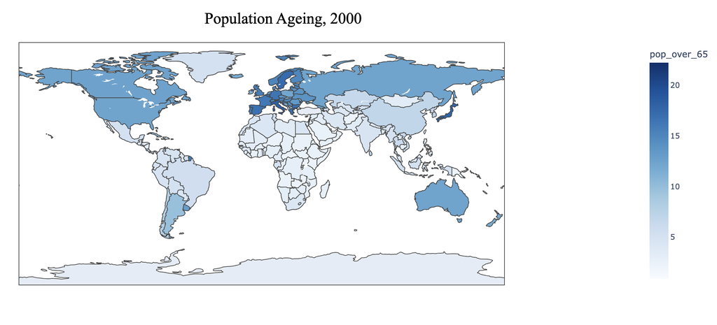

```python
# Show the top 5 countries with highest fraction of population ages 65 and above in 2020

wb_population_2020 = wb_population_20years[wb_population_20years['year']==2020].sort_values(by='pop_over_65', ascending=False)

wb_population_2020.head(5)
```

| Series Name | Country Name | year | pop_over_65 | fertility | life_expectancy | mortality_infant | death_rate |
| --- | --- | --- | --- | --- | --- | --- | --- |
| 430 | Monaco | 2020 | 35.849900 | .. | .. | 1 | .. |
| 386 | Japan | 2020 | 29.583178 | 1.33 | 84.56 | 1.8 | 11.1 |
| 384 | Italy | 2020 | 23.372071 | 1.24 | 82.1951219512195 | 2.4 | 12.5 |
| 347 | Finland | 2020 | 22.490093 | 1.37 | 81.9317073170732 | 1.8 | 10 |
| 462 | Portugal | 2020 | 22.296726 | 1.41 | 80.9756097560976 | 2.7 | 12 |

```python
# Draw the Population Ageing Distribution World Map in 2020

fig2 = px.choropleth(wb_population_20years[wb_population_20years['year'] == 2020],
                    locations='Country Name',
                    locationmode="country names",
                    scope="world",
                    color='pop_over_65',
                    color_continuous_scale='Blues')

fig2.update_layout(
      title_text = 'Population Ageing, 2020',
      title_font_family="Times New Roman",
      title_font_size = 25,
      title_font_color="black",
      title_x=0.5)
```

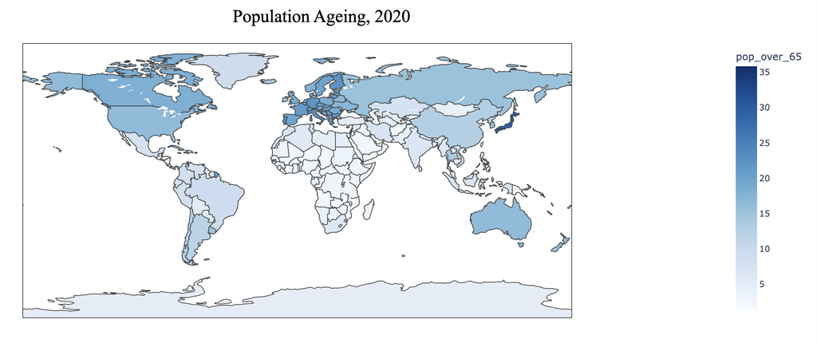

Yes, population ageing is becoming a global issue gradually. 87 countries were in the population ageing stage in 2000 while 138 countries were in population ageing society in 2020. It means 51 countries entered the population ageing society between those 20 years. Monaco, Japan, and Italy were in the top 5 list both in 2000 and in 2020. The fraction of population ages 65 and above in Monaco reached almost 36% which means an extremely high burden for younger people to raise senior people. From the population ageing distribution in the world, it seems the issue is more severe in developed countries than in developing countries.

1. The life expectancy at birth - What can we tell from the life expectancy trend?

```
year
2000    Axes(0.125,0.11;0.775x0.77)
2020    Axes(0.125,0.11;0.775x0.77)
Name: life_expectancy, dtype: object
```

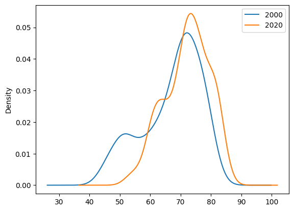

```python
# Show the density plot of life expectancy and the trend from 2000 to 2020

wb_population_20years['life_expectancy'] = wb_population_20years['life_expectancy'].replace('..', np.nan)

wb_population_20years['life_expectancy'] = wb_population_20years['life_expectancy'].astype(float)

wb_population_20years.groupby('year').life_expectancy.plot.density(legend=True)
```

The overall distribution of life expectancy shifts to the right showing an increased average life expectancy and a less dispersed distribution from 2000 to 2020. People generally can live longer than 20 years ago.

1. Fertility rate - What can we tell from the fertility rates changes?

```
year
2000    Axes(0.125,0.11;0.775x0.77)
2020    Axes(0.125,0.11;0.775x0.77)
Name: fertility, dtype: object
```

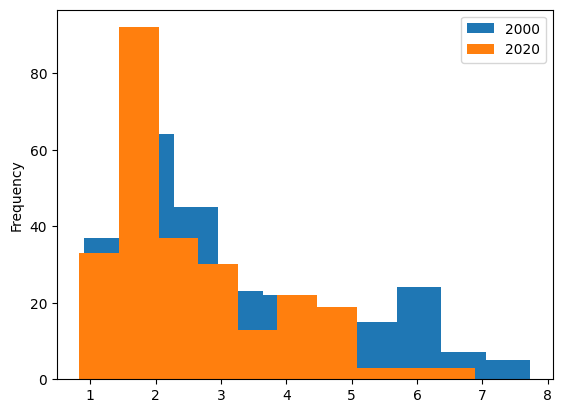

```python
# Show the distribution of fertility rates and changes from 2000 to 2020

wb_population_20years['fertility'] = wb_population_20years['fertility'].replace('..', np.nan)

wb_population_20years['fertility'] = wb_population_20years['fertility'].astype(float)

wb_population_20years.groupby('year').fertility.plot.hist(legend=True)
```

Summary:

1. By comparing the ratio of population ages 65 and above, life expectancy, and fertility rate in 2000 and 2020, we have more countries are encountering population ageing challenges.
2. The increased life expectancy and declined fertility rates are two major direct driving forces.
3. To find more patterns behind it, we can present the dynamic changes among two or three typical countries using this dataset and try to connect this trend with other factors such as GDP per capita, health status, educational attainment, and technological development in the future work.